# Finale BUS 310

Derrick O

2025-12-04

# Problem 1

### Importing dataset

The dataset contains NBA data on team statistics from the 2022/23 – 2024/25 seasons.

```r
nba <- read.csv("~/Desktop/Bus Analytics/exam.csv")
View(nba)
```

### Setting seed number

I chose 6 as my seed number as this is number of the central midfield position that I play in soccer.

```r
set.seed(6)
```

### Loading Libraries

```r
library(cluster)
library(factoextra)
```

### Reading the file and creating a dataframe

```r
df = read.csv("~/Desktop/Bus Analytics/exam.csv")
```

### Standardizing variables

Due to the data containing team names which is categorical, I decided to only include the three variables that I will be using for my analysis. They include: 3PA, 3P% and PTS.

```r
df_numeric = df[, c("X3PA", "X3P.", "PTS")]
dfsc = scale(df_numeric)
```

### Optimal number of clusters

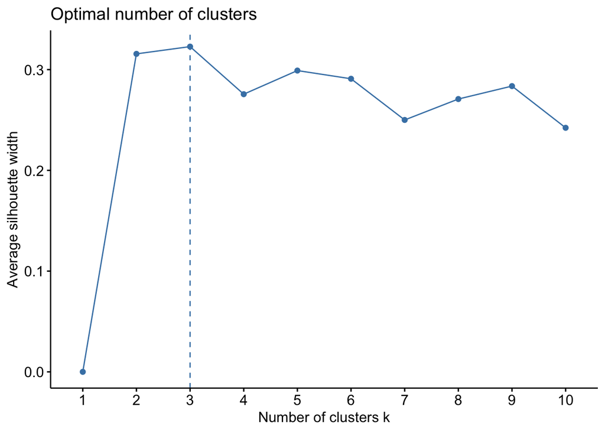

```r
fviz_nbclust(dfsc, kmeans, method="silhouette")
```

### Executing K-,means clustering with k=3

```r
k3 = kmeans(dfsc, centers = 3, nstart = 1000)
k3
```

```
## K-means clustering with 3 clusters of sizes 25, 40, 25
##
## Cluster means:
##         X3PA       X3P.        PTS
## 1  1.1470065  0.6182081  0.8854009
## 2 -0.5848593  0.3604515  0.1650927
## 3 -0.2112316 -1.1949305 -1.1495493
##
## Clustering vector:
##  [1] 1 1 2 1 1 1 2 1 2 2 1 2 1 2 2 1 1 1 2 2 3 3 3 2 3 3 3 3 3 3 1 1 2 1 1 2 1 1
## [39] 1 2 2 2 2 2 2 2 3 2 2 2 3 2 3 3 3 2 3 3 3 3 1 1 2 1 2 2 1 2 1 1 2 2 2 2 2 1
## [77] 2 2 2 2 2 2 3 3 2 3 3 3 3 3
##
## Within cluster sum of squares by cluster:
## [1] 34.28237 47.03756 33.81838
##  (between_SS / total_SS =  56.9 %)
##
## Available components:
##
## [1] "cluster"      "centers"      "totss"        "withinss"     "tot.withinss"
## [6] "betweenss"    "size"         "iter"         "ifault"
```

### Appending Observation cluster assignment

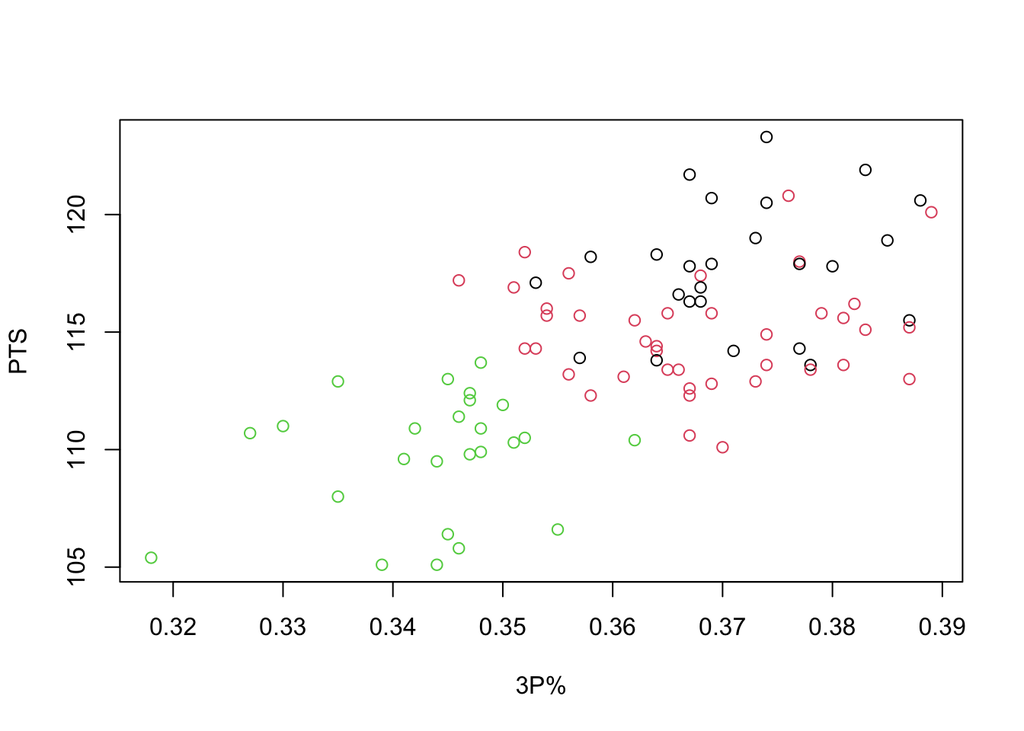

```r
df_k3 = cbind(df, clusterID = k3$cluster)
plot(df_k3$X3P., df_k3$PTS, col=factor(df_k3$clusterID),xlab='3P%', ylab = 'PTS')
```

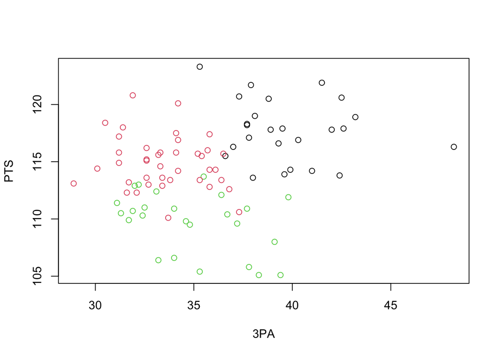

```r
# Appending Observation cluster assignment
df_k3 = cbind(df, clusterID = k3$cluster)
plot(df_k3$X3PA, df_k3$PTS, col=factor(df_k3$clusterID),xlab='3PA', ylab = 'PTS')
```

### Calculating Averages

```r
# cluster 1 averages
mean(df_k3$X3P.[df_k3$clusterID==1])
```

```
## [1] 0.37136
```

```r
mean(df_k3$PTS[df_k3$clusterID==1])
```

```
## [1] 117.72
```

```r
# cluster 2 averages
mean(df_k3$X3P.[df_k3$clusterID==2])
```

```
## [1] 0.367425
```

```r
mean(df_k3$PTS[df_k3$clusterID==2])
```

```
## [1] 114.8925
```

```r
# cluster 3 averages
mean(df_k3$X3P.[df_k3$clusterID==3])
```

```
## [1] 0.34368
```

```r
mean(df_k3$PTS[df_k3$clusterID==3])
```

```
## [1] 109.732
```

### Interpretation & Motivation

In 2018, as a Houston Rockets fan, I watched my then team collapse in the WCF against Golden State after missing 27 straight threes. It was an important moment that made me question why NBA teams are so committed to copying the Warriors’ high-volume three-point identity. Houston was shooting 62% from mid-range and consistently getting clean looks inside, especially with Golden State lacking a true rim protector in their effort for a ‘small ball’ lineup, yet they abandoned what was working and still attempted 44 threes, finishing just 7 for 44. Watching a team with capable scorers (not shooters) force a strategy so misaligned with the team’s ability made me question whether the league’s obsession with replicating Golden State is actually justified.

To explore this, I analyzed three variables: 3PA, 3P%, and PTS. All while using k-means clustering to segment NBA teams into offensive groupings. My goal was to see whether taking more threes truly leads to higher scoring, or whether efficiency is the real driver behind elite offenses.